# Does getting married make you bad at Mario?

In collaboration with 2 group members

```r
#load packages
pacman::p_load(mosaic,ggthemes,ggsci, car, patchwork, pander,tidyverse)

cl_res <- function(aovout){
  temp <- max(abs(aovout$residuals))
  plot(aovout$fitted.values, aovout$residuals, xlab = "Fitted Values",
       ylab = "Residuals", main = "Equal Variance Check", pch = 16,
      ylim = c(-temp, temp))
  abline(h=0, col = "gray", lty = 2)
}
#read in dataset in wide format, pivot to long format for analysis
mario <- read_csv("mario.csv")
mariol <- pivot_longer(mario, values_to = "Time", cols = c("Married", "Single"))
mariol <- dplyr::rename(mariol, m_status = name)

#clean data, create analysis variables, set factors as such
mariol$cTime <- mariol$Time-mariol$Covariate
mariol$m_status <- as.factor(mariol$m_status)
mariol$Experience <- as.factor(mariol$Experience)
mariol$Map <- as.factor(mariol$Map)
#create ggplottable dummy variables

mariol <- mutate(mariol,
                 expd = case_when(Experience == "None" ~ 1,
                                          Experience == "Some" ~ 2,
                                          Experience == "Lots" ~ 3),
                 m_statusd = case_when(m_status == "Married" ~ 1,
                                       m_status == "Single" ~ 0),
                 logTime = log(Time),
                 logcTime = log(cTime))

#create model
mova <- lm(Time ~ Covariate + m_status * Experience, data = mariol, contrasts = list(m_status = contr.sum, Experience = contr.sum))

lmova <- lm(logTime ~ Covariate + m_status * Experience, data = mariol, contrasts = list(m_status = contr.sum, Experience = contr.sum))

cmova <- lm(cTime ~ Covariate + m_status * Experience, data = mariol, contrasts = list(m_status = contr.sum, Experience = contr.sum))
```

## Introduction

Ever since the invention of video games, opinions have been split about their value and appropriate use. While some enjoy video games a lot and play them frequently, others eschew the practice entirely. In the Intermountain West and especially at BYU-I, it has been observed by the authors that the majority of those gaming enthusiasts are single. This raises a question: are gamers single because that makes you a better gamer, or are they single because it makes them less dateable? Answering the second question is outside the scope of this study, but the first can potentially be answered through it’s reverse, using an archetypal game which has existed almost as long as video games themselves. In other words; *does getting married make you bad at Mario?* We will analyze this question using a convenience sample of those in the Rexburg community who self-identified as gamers or otherwise. To provide an accurate measurement, we will compare the time it takes to complete a Mario Maker 2 map between single and married individuals, controlling for other factors as discussed in the Methods section and performing an Analysis of Covariance, or ANCOVA, of the results. This procedure infers the following hypotheses:

#### Hypotheses

First Hypothesis: Marital status affects gaming skill

$$H_0: \alpha_M = \alpha_S = 0 \\
H_a: \alpha_i \ne 0 \text{ for at least one } i \in \{M =
\text{Married}, S = \text{Single}\}$$

Second Hypothesis: Experience level affects gaming skill

$$H_0: \alpha_N = \alpha_S = \alpha_L = 0 \\
H_a: \alpha_i \ne 0 \text{ for at least one } i \in \{N = \text{No
experience}, S = \text{Some experience}, L = \text{Lots of Experience}\}$$

Third Hypothesis: There is an interaction between Marital Status and Gaming Experience
$$H_0: \text{The effect of Marital Status is the same for all levels of
Experience} \\
H_a: \text{The effect of Marital Status is not the same for all levels
of Experience}$$

We will use this model to analyze these hypotheses:

$$Y_{ijk} = \mu + \alpha_i + \beta_j + \alpha\beta_{ij} + \tau_k +
\epsilon_{ijk}$$
where $Y_{ijk}$ is the time to complete the map, $\mu$ is the benchmark or grand average of all times, $\alpha_i$ is the effect of the experience level of the participant, $\beta_j$ is the effect of the marital status of the participant, $\alpha\beta_{ij}$ is the effect of the interaction between the two factors, $\tau_k$ is the effect of our covariate measure, and $\epsilon_{ijk}$ is the residual error.

Level of significance for this analysis is set at $\alpha = .05$.

## Methods

In order to collect quantitative data analyzing Mario skill, we selected to measure the elapsed time between beginning a level and completing it. Those who finish faster demonstrate more skill, while those who die frequently or are less capable at navigating the obstacles of a Mario level will take longer to do so.

To provide accessibility, Mario Maker 2 on the Nintendo Switch was selected as a representative Mario game which is also portable. Research participants played in the Handheld mode using standard Joy-Cons. The particpants were convenience sampled according to those willing and availiable to participate in the research, and sorted into 3 groups with two members each:

- Those who never or only very rarely play video games
- Those who play some but not many video games
- Those who are experienced gamers and play frequently

In each group there was a single and a married participant. This allows us to treat both Marital Status and Gaming Experience as crossed, fixed factors with 2 and 3 levels respectively.

To ensure that this experiment would represent all potential Mario Maker experiences (and therefore all video game experiences), the map selected to play upon was treated as a random variable with 6 levels. Each experience level was assigned two maps, then the players in that experience group played both maps and recorded their times. This means that from a sample of 6 students, we received 12 data points. Because the sample size is small, we will assume interaction between the covariate and our other factors is negligible, thus allowing us the degrees of freedom to perform an inferential test.

It was originally intended to use the selected map as a blocking variable, but further design consideration revealed that it would be best to utilize a covariate instead. An expert gamer was selected who played all the maps with the same conditions as the research participants. His times are used as a covariate to control for any differences between Mario Maker maps, and this effect is added into the model as $\tau_k$.

## Analysis

#### Diagnostic plots and Transformation

Having collected the data, we may analyze the appropriateness of ANCOVA. We will examine a Residuals vs. Fitted plot for equal variance and linear relationship (no noticeable patterns in the plot will show those to be true), and a QQ plot of the residuals for normal distribution (following the projected line shows this assumption):

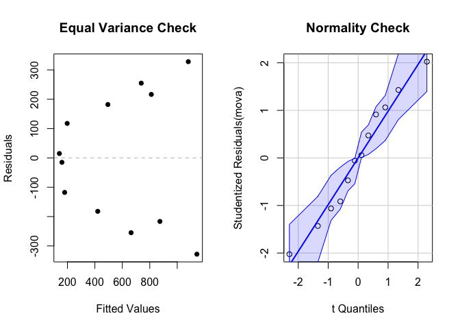

```r
par(mfrow = c(1,2))
cl_res(mova)
qqPlot(mova, id = F, main = "Normality Check")
```

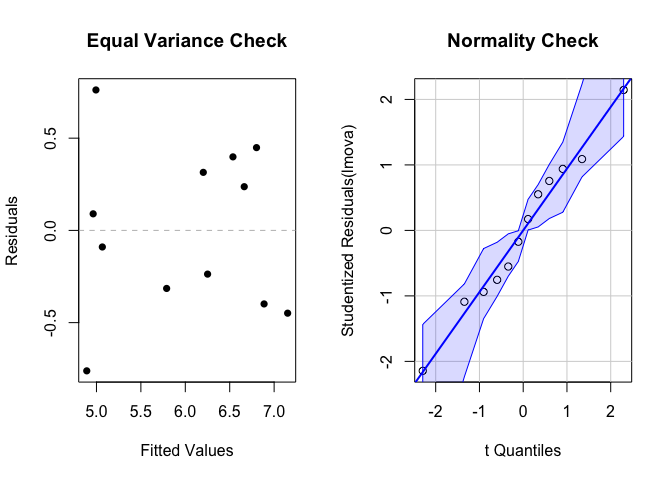

```r
par(mfrow = c(1,2))
cl_res(lmova)
qqPlot(lmova, id = F, main = "Normality Check")
```

That looks much better! Now our Residuals Vs. Fitted plot and our QQ plot fall within the parameters we want and we can proceed with the analysis.

#### Visualizing the Data

Looking at the plot below of Log transformed time to complete each map, we can clearly see a downward trend as experience increases. However, it will be necessary to examine the results of an ANCOVA before making any claims about whether that trend is statistically significant.

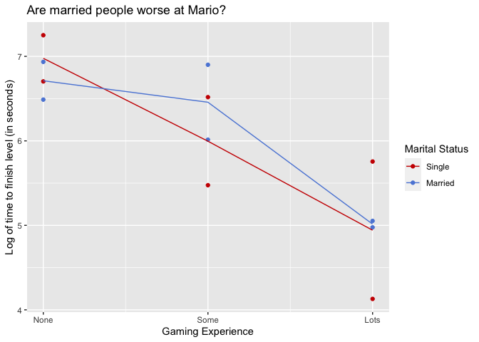

```r
t <- ggplot(mariol, aes(x = expd, y = logTime, color = as.factor(m_statusd))) +
  geom_point() +
  scale_color_startrek(name = "Marital Status", labels = c("Single", "Married"))  +
  stat_summary(fun = mean, geom = "line") +
  scale_x_continuous(breaks = c(1,2,3), labels = c("None", "Some", "Lots"))

t + labs(title = "Are married people worse at Mario?",
         y = "Log of time to finish level (in seconds)",
         x = "Gaming Experience")
```

It is also important to remember that with the covariate adjustment, we may see a different pattern in the plot. Therefore, here is a side by side comparison of the two plots. If the covariate is very impactful, we will see a far different (probably flatter) pattern in the covariate adjusted plot.

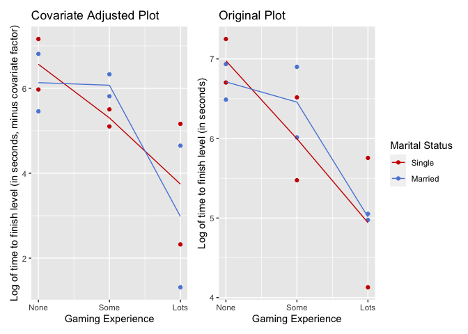

```r
c <- ggplot(mariol, aes(x = expd, y = logcTime, color = as.factor(m_statusd))) +
  geom_point() +
  scale_color_startrek() +
  labs(title = "Covariate Adjusted Plot",
       y = "Log of time to finish level (in seconds, minus covariate factor)",
       x = "Gaming Experience") +
  stat_summary(fun = mean, geom = "line") +
  scale_x_continuous(breaks = c(1,2,3), labels = c("None", "Some", "Lots")) +
  theme(legend.position = "none")

t <- t + labs(title = "Original Plot", y = "Log of time to finish level (in seconds)", x = "Gaming Experience")
c + t
```

It does not appear that this is the case. In fact, the pattern appears so similar that it is doubtful the covariate will have any effect upon the results of our ANCOVA shown below.

#### Test Results

```r
pander(Anova(cmova, type = 3), caption = "Type III Sum of Squares")
```

Type III Sum of Squares

|  | Sum Sq | Df | F value | Pr(>F) |
| --- | --- | --- | --- | --- |
| **(Intercept)** | 1042677 | 1 | 9.773 | 0.02607 |
| **Covariate** | 142596 | 1 | 1.337 | 0.2999 |
| **m_status** | 1386 | 1 | 0.01299 | 0.9137 |
| **Experience** | 950179 | 2 | 4.453 | 0.07752 |
| **m_status:Experience** | 131848 | 2 | 0.6179 | 0.5757 |
| **Residuals** | 533458 | 5 | NA | NA |

## Conclusion

While we did not identify any significant p-values, this analysis was nonetheless very informative. In all our testing, it was obvious that those who have never played video games had more difficulty navigating the maps we randomly selected. The fact that this experience factor was not found to be significant may be due to the small nature of our sample size. Because there are only 4 data points for each experience level and 6 per marital status, it is difficult to generalize from these results to the population; a difficulty only increased by the convenience sampled nature of the study. Therefore, it may be very useful in ascertaining the true answers to our questions to perform another, similar study with a much larger scope.